```python
import os
import timeit
import operator
import numpy as np
import pandas as pd
import seaborn as sns; sns.set()
import scipy.stats as st
import matplotlib.pyplot as plt

from tqdm import tqdm
from sklearn import metrics
from collections import Counter
from scipy.spatial import distance
from sklearn.cluster import KMeans
from sklearn.metrics import pairwise_distances
from sklearn.neighbors import KernelDensity
import supporting_functions as sf
import hypercubes

%load_ext autoreload
%autoreload 2
```

# Layered Integration Approach for Multi-view Analysis of Real-world Datasets

In this notebook we validate the *Layered Integration Approach for Multi-view Analysis of Real-world Datasets*.

The proposed layered integration methodology is demonstrated on SCADA data from the wind turbine dataset from [Engie](https://opendata-renewables.engie.com/explore/index). In this dataset 8 years of data from 4 wind turbines is available. This is an excellent example of a multi-source (multiple wind turbines) and multi-view (multiple different in nature subsets of parameters) dataset, which is exactly where the layered integration approach is designed for.

The initial aim of the studied experimental scenario is to identify and **characterise potentially different operating modes across the fleet**. Notice that wind turbines can have several different operating modes, e.g. working at full speed, reduced speed in order to limit the noise burden on the surroundings, tailored production due to oversupply on the net and others. Subsequently, the ultimate goals is to **derive distinctive profiles of production performance** and establish an explicit link between those performance profiles and the characterised operating modes.

# 1 Overview of the Engie Dataset

The dataset should be first downloaded from [here](https://opendata-renewables.engie.com/explore/index), and the path should be changed.

As one can in the plots below, the 4th wind turbine has a big loss of values between 2013 and 2014.

```python
DATA_DIR='../../../Hymop_Engie/repository/hymop-Engie/data/'

df_engie = pd.read_csv(DATA_DIR + 'extended_clean_sensor_data.csv', parse_dates=[0])

print("Amount of entries in database: \t"+ str(df_engie.shape[0]))
print("Amount of wind turbines: \t"+str(len(df_engie.Wind_turbine_name.unique())))
print("Amount of features: \t\t"+ str(df_engie.shape[1]))

print("\nstart: \t"+str(min(df_engie.Date_time)))
print("end: \t"+str(max(df_engie.Date_time)))
```

```
Amount of entries in database: 	1654811
Amount of wind turbines: 	4
Amount of features: 		31

start: 	2009-01-01 00:10:00+01:00
end: 	2017-04-01 00:00:00+02:00
```

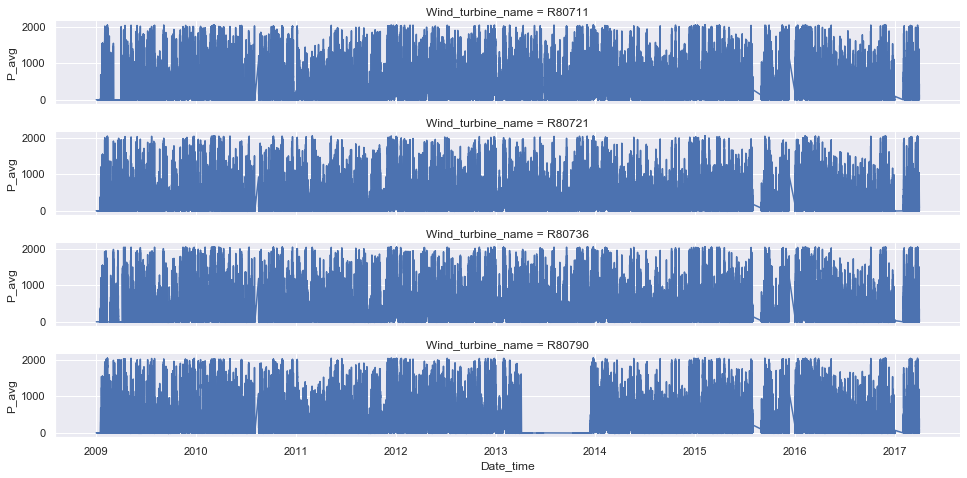

```python
g = sns.FacetGrid(df_engie.reset_index(), row="Wind_turbine_name", height=1.7, aspect=8);
g.map(sns.lineplot, "Date_time", "P_avg");
```